# Charcoal concentrations

First and foremost, I want to test the relationship between charcoal concentration and depth (later I’ll move on to working with the other variables).

Here’s the data I’m working with:

```r
char_mass <- read.csv("char_mass_sieve.csv")
attach(char_mass)
char_mass
```

| Site_id | sample_id | depth..mm. | dry.weight | mass...2.mm. | mass....0.5.mm. | total.mass |
| --- | --- | --- | --- | --- | --- | --- |
| RIDG_01 | A | 0-50 | 2.58500 | NA | 0.0001 | 0.0001 |
| RIDG_01 | B | 50-100 | 35.39000 | 0.0001 | NA | 0.0001 |
| RIDG_01 | C | 100-150 | 56.19800 | 0.0609 | NA | 0.0609 |
| RIDG_01 | D | 150-200 | 110.58100 | 0.1097 | NA | 0.1097 |
| RIDG_01 | E | 200-250 | 90.04000 | 0.0323 | NA | 0.0323 |
| RIDG_01 | F | 250-300 | 116.88300 | NA | 0.3304 | 0.3304 |
| RIDG_01 | G | bottom | 42.22800 | NA | 0.0046 | 0.0046 |
| RIDG_02 | A | 0-50 | 9.69000 | 0.0078 | 0.0038 | 0.0116 |
| RIDG_02 | B | 50-100 | 73.97000 | 0.0387 | NA | 0.0387 |
| RIDG_02 | C | 100-150 | 100.56400 | 0.0859 | NA | 0.0859 |

[output cut: 109 more lines]

Before I start working with it, I want to clean up a few things: - The NAs in the >2 mm mass column should all get set to zero

```r
char_mass$mass...2.mm.[which(is.na(char_mass$mass...2.mm.))] <- 0
```

## Bulk Density

To get charcoal concentration, I need to first calculate bulk density. The equation for bulk density (BD) that I’ll be using is BD (gram/cubic centimeter) = dry soil weight (grams) / soil volume (cubic centimeter). The height and diameter of the soil rings we used is both 5 cm, so the volume of the ring is pi x radius squared x height. This comes out to 98.175 cubic centimeters (rounded). I’ll be using the dry soil weight from the KMD data, since the sieved samples were never dried. I’ve calculated bulk density in excel already, but here’s the code for incorporating into R.

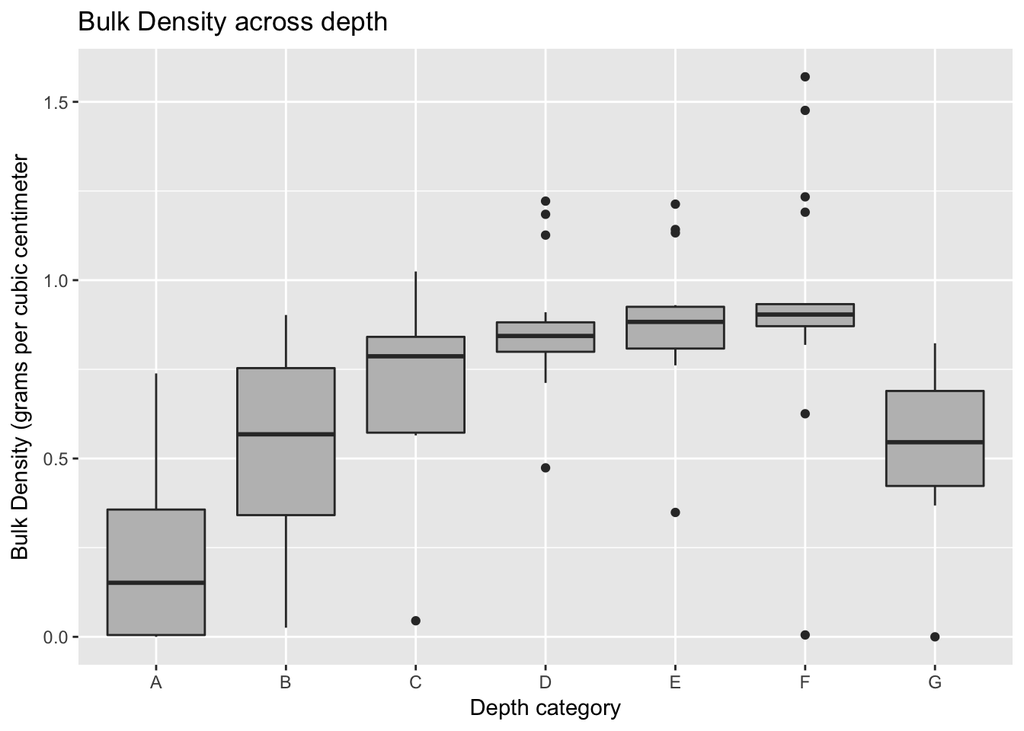

```r
ring_volume <- pi * 2.5^2 * 5 # 98.17477

# adding column to char_mass for bulk density
char_mass$bulk_density <- (dry.weight/ring_volume)

# exploring relationship between bulk density and depth
ggplot(char_mass) + geom_boxplot(aes(char_mass$sample_id, char_mass$bulk_density), fill = "grey") + labs(x = "Depth category", y = "Bulk Density (grams per cubic centimeter", title = "Bulk Density across depth")
```

```r
# I also want to check the relationship between average bulk density and depth
av_bulk_density <- tapply(bulk_density, depth..mm., mean)
```

```
## Error in tapply(bulk_density, depth..mm., mean): object 'bulk_density' not found
```

```r
plot(av_bulk_density)
```

```
## Error in plot(av_bulk_density): object 'av_bulk_density' not found
```

So bulk density looks like it’s lowest in surface soils, and highest in the deeper samples. I would’ve expected the very deepest soils to be the densest, but since we didn’t always recover a full sample from those depths, maybe the dry weight is underreflecting density?